# Estimation de la fonction de survie en présence de données censurés

```r
library(ggplot2)
library(gridExtra)
library(survival)
library(microbenchmark)
library(xtable)
library(ggthemes)
library(readr)
library(dplyr)
library(kableExtra)
setwd(dirname(rstudioapi::getActiveDocumentContext()$path))
```

# Etude de simulation

Nous allons générer des données suivant un modèle hyper-exponentielle $\text{H-Exp}(p = 0.75, \mu_1 = 2, \mu_2 = 1/2)$ de densité

$$f(t) = p\frac{e^{-t/\mu_1}}{\mu_1} +
(1-p)\frac{e^{-t/\mu_2}}{\mu_2},\text{ pour } t>0.$$
Deux fonctions pour générer des données et calculer la fonction de survie

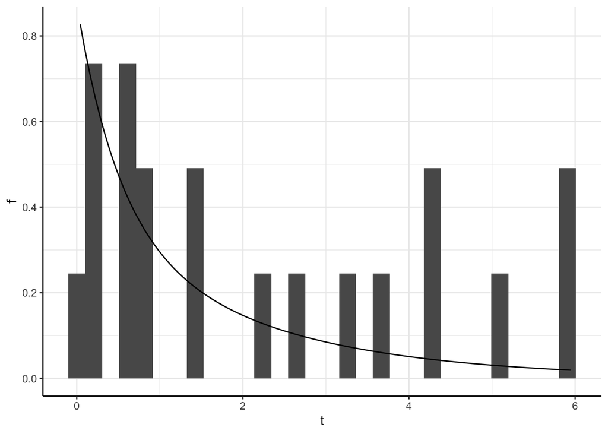

```r
rhexp <- function(n, p, mu1, mu2){
  I <- rbinom(n, 1, p)
  I * rexp(n, 1 / mu1) + (1 - I) * rexp(n, 1 / mu2)
}

Shexp <- function(t, p, mu1, mu2){
  p * exp(-t / mu1) + (1-p) * exp(-t / mu2)
}

n <- 20; p <- 0.75; mu1 <- 2; mu2 <- 1 / 2
Ts <- rhexp(n, p, mu1, mu2)
ggplot() + geom_histogram(data = data.frame(Ts), mapping = aes(x = Ts, y = ..density..)) + geom_function(fun = function(t) p * exp(-t / mu1) / mu1 + (1-p) * exp(-t / mu2) / mu2) + labs(x ="t", y = "f") + theme_bw() +
  theme(panel.border = element_blank(),
    panel.background = element_blank(), axis.line = element_line(colour = "black"))
```

Les données non censurées sont notées $t_1,\ldots, t_n$. Les données disponibles sont de la forme suivante:
$$(x_i, \delta_i) = (t_i\land c_i,\mathbb{I}_{t_i \geq c_i}),\text{ }i =
1, \ldots, n.$$
L’estimateur standard de la fonction de survie empirique

$$S_{\text{emp}}(t) = \frac{1}{n}\sum_{i=1}^n\mathbb{I}_{t_i>t}$$
est remplacé en présence de censure par

$$S_{\text{emp}}(t) =
\frac{\sum_{i=1}^n\mathbb{I}_{x_i>t}}{\sum_{i=1}^n\mathbb{I}_{x_i>t}
+ \sum_{i=1}^n\mathbb{I}_{x_i\leq t}\delta_i}$$
La fonction renvoie une estimation de la fonction de survie et son intervalle de confinace de niveau $\alpha$.

```r
Xs <- Ts; del = rep(1, length(Ts)); alpha <- 0.95
S_emp <- function(t, del, Xs, alpha){
  est <- sum(Xs > t) /(sum(Xs > t) + sum(Xs[as.logical(del)] <= t))
  z <- qnorm(alpha)
  c(est, max(0,est - z * sqrt(est * (1 - est) / (sum(Xs > t) + sum(Xs[as.logical(del)] <= t)))),
    min(1,est + z * sqrt(est * (1 - est) / (sum(Xs > t) + sum(Xs[as.logical(del)] <= t))))
  )
}
```

Supposons que $T$ soit discrète à valeur dans $\{v_0,v_1,\ldots,\}$ tel que $0=v_0<v_1<\ldots$. L’estimateur de Kaplan-Meier est donnée par

$$\widehat{S_n}^{\text{KP}}(t) = \prod_{k: v_k\leq
t}\left[1-\frac{d(v_k)}{n(v_k)}\right],$$
où $d(v_k) = \sum_{i = 1}^n\delta_i\mathbb{I}_{x_i\in [v_k,v_{k+1})}$ et $n(v_k) = \sum_{i = 1}^n\mathbb{I}_{x_i\geq v_k}$.

La fonction suivante calcule l’estimateur de KP avec son intervalle de confiance.

```r
KP <- function(t, del, Xs, h, alpha = 0.95){
  # Grille de point, les v_k
  grid <- c(seq(0, ceiling(max(Xs)), h), Inf)
  # Définition des d(v_k)
  Xs_dis <- grid[findInterval(Xs, grid)]
  dk <- sapply(grid, function(t) sum(Xs_dis[as.logical(del)] == t))
  # d(v_k) sans les données censurées
  dk_all <- sapply(grid, function(t) sum(Xs_dis == t))
  n <- length(Xs)
  nk <- c(n, n-cumsum(dk_all))[1:length(dk)]


  ds <- dk[1:findInterval(t, grid)]
  ns <- nk[1:findInterval(t, grid)]
  # Estimateur de KP
  est <- prod(1 - ds[ds>0]/ ns[ds>0])
  # Variance du log de l'estimateur de KP
  VlnKP <- sum(ds / (ns -ds) / ns)
  # Quantile de la loi normale
  z <- qnorm(alpha)
  # Estimateur et interbvalle de confiance
  c(est,
    max(est - z * est * sqrt(VlnKP),0),
    min(est + z * est * sqrt(VlnKP),1)
    )
}
```

## Données non censuré

Lorsque les données ne sont pas censurées, l’estimateur de Kaplan Meier coincide avec l’estimateur standard de la fonction de survie. On vérifie que l’on obtient bien la même chose qu’avec la fonction **survfit** du paquet **survival**.

```r
Xs <- Ts; del = rep(1, length(Ts)); alpha <- 0.95
result.km <- survfit(Surv(Xs, del) ~ 1)
h <- 0.001; alpha <- 0.95
t <- 1
KP(t, del, Xs, h, alpha); S_emp(t, del, Xs, alpha);c(result.km$surv[findInterval(t, result.km$time)], result.km$lower[findInterval(t, result.km$time)],result.km$upper[findInterval(t, result.km$time)]); Shexp(t, p, mu1, mu2)
```

```
## [1] 0.5500000 0.3670216 0.7329784
```

```
## [1] 0.5500000 0.3670216 0.7329784
```

```
## [1] 0.5500000 0.3699974 0.8175733
```

```
## [1] 0.4887318
```

Notre fonction qui calcule l’estimateur de Kaplan-Meier est un peu lente. Nous pouvons proposer une version plus rapide qui s’affranchit du choix de $h$ en utilisant les observations pour définir la grille de points. On utilise la library **microbenchmark** pour comparer les deux fonctions.

```r
KP_fast <- function(t, del, Xs, alpha = 0.95){
  grid <- c(0, sort(Xs), Inf)
  # Définition des d(v_k)
  dk <- sapply(grid, function(t) sum(Xs[as.logical(del)] == t))
  dk_all <- sapply(grid, function(t) sum(Xs == t))
  n <- length(Xs)
  nk <- c(n, n-cumsum(dk_all))[1:length(dk)]
  ds <- dk[1:findInterval(t, grid)]
  ns <- nk[1:findInterval(t, grid)]

  # Estimateur de KP
  est <- prod(1 - ds[ds>0]/ ns[ds>0])
  # Variance du log de l'estimateur de KP
  VlnKP <- sum(ds / (ns -ds) / ns)
  # Quantile de la loi normale
  z <- qnorm(alpha)
  # Estimateur et interbvalle de confiance
  c(est,
    max(est - z * est * sqrt(VlnKP),0),
    min(est + z * est * sqrt(VlnKP),1)
    )

}
Xs <- Ts; del = rep(1, length(Ts)); alpha <- 0.95
h <- 0.001; alpha <- 0.95; t <- 1.15154;
microbenchmark(KP(t, del, Xs, h, alpha), KP_fast(t, del, Xs, alpha))
```

[output not shown]

[output cut: 190 more lines]

On utilise la version rapide de la fonction pour tracer la fonction de survie empirique.

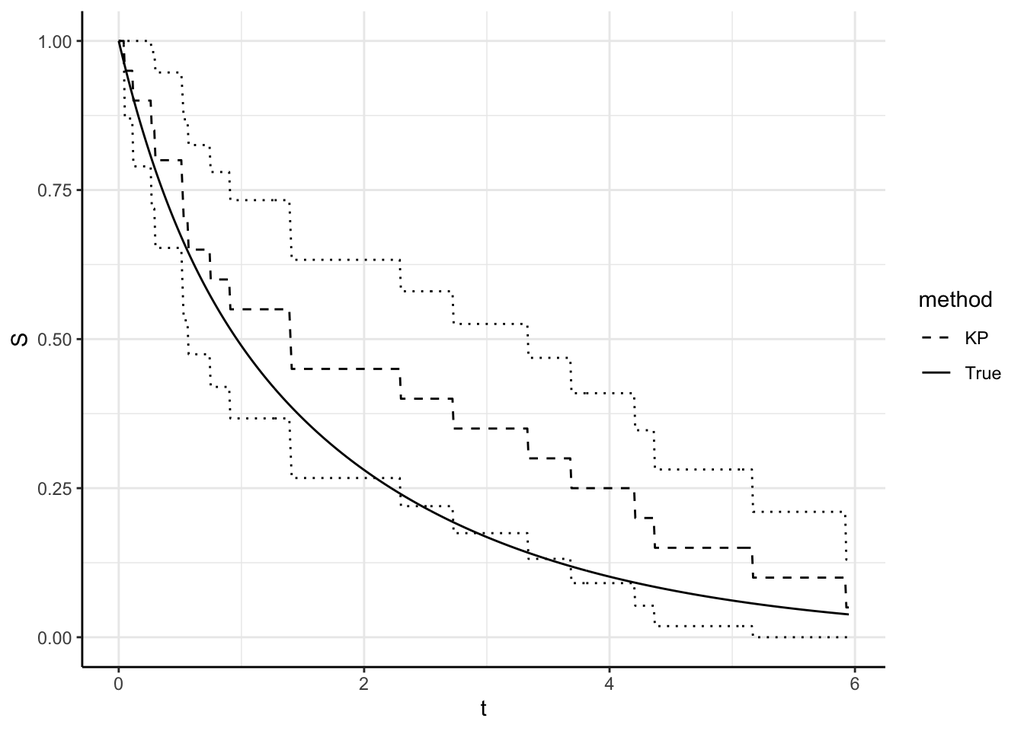

```r
t_grid  =seq(0, max(Ts), 0.01)
df_S_KP <-data.frame(cbind(t_grid, t(sapply(t_grid, function(t) KP_fast(t, del, Xs, alpha)))))
colnames(df_S_KP) <- c("ts", "S_hat", "lower", "upper")
df_S_KP["method"] = "KP"

df_S_true = data.frame(ts = t_grid,
                      S_hat = sapply(t_grid, function(t) Shexp(t, p, mu1, mu2)),
                      lower = sapply(t_grid, function(t) Shexp(t, p, mu1, mu2)),
                      upper = sapply(t_grid, function(t) Shexp(t, p, mu1, mu2)),
                      method = "True"
                      )

ggplot() + geom_line(data = rbind(df_S_KP, df_S_true), mapping = aes(x = ts, y = S_hat, linetype = method)) + scale_linetype_manual(values=c("dashed", "solid")) + geom_line(data = df_S_KP, mapping = aes(x = ts, y = lower), linetype = "dotted") + geom_line(data = df_S_KP, mapping = aes(x = ts, y = upper), linetype = "dotted")  +
  labs(x ="t", y = "S") + theme_bw() +
  theme(panel.border = element_blank(),
    panel.background = element_blank(), axis.line = element_line(colour = "black"))
```

## Donnée censurées

On applique maintenant une censure de type 3 sur les données. Voyons la différence entre l’estimateur de Kaplan Meier et l’estimateur standard qui ne va prendre en compte que les données non censuré.

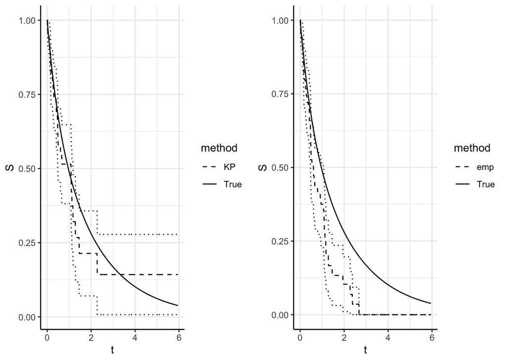

```r
Ts <- rhexp(50, p, mu1, mu2);Cs <- rexp(50, 2/(mu1 + mu2)); Xs <- pmin(Ts, Cs); del = as.integer(Ts < Cs); alpha <- 0.95
t_grid  =seq(0, max(Ts), 0.01)

df_S_KP <-data.frame(cbind(t_grid, t(sapply(t_grid, function(t) KP_fast(t, del, Xs, alpha)))))
colnames(df_S_KP) <- c("ts", "S_hat", "lower", "upper")
df_S_KP["method"] = "KP"

df_S_emp <-data.frame(cbind(t_grid, t(sapply(t_grid, function(t) S_emp(t, del, Xs, alpha)))))
colnames(df_S_emp) <- c("ts", "S_hat", "lower", "upper")
df_S_emp["method"] = "emp"


df_S_true = data.frame(ts = t_grid,
                      S_hat = sapply(t_grid, function(t) Shexp(t, p, mu1, mu2)),
                      lower = sapply(t_grid, function(t) Shexp(t, p, mu1, mu2)),
                      upper = sapply(t_grid, function(t) Shexp(t, p, mu1, mu2)),
                      method = "True"
                      )

KP_plot <- ggplot() + geom_line(data = rbind(df_S_true, df_S_KP), mapping = aes(x = ts, y = S_hat, linetype = method)) + scale_linetype_manual(values=c("dashed", "solid")) + geom_line(data = df_S_KP, mapping = aes(x = ts, y = lower), linetype = "dotted") + geom_line(data = df_S_KP, mapping = aes(x = ts, y = upper), linetype = "dotted")  +
  labs(x ="t", y = "S") + theme_bw() +
  theme(panel.border = element_blank(),
    panel.background = element_blank(), axis.line = element_line(colour = "black"))

S_emp_plot <- ggplot() + geom_line(data = rbind(df_S_true, df_S_emp), mapping = aes(x = ts, y = S_hat, linetype = method)) + scale_linetype_manual(values=c("dashed", "solid")) + geom_line(data = df_S_emp, mapping = aes(x = ts, y = lower), linetype = "dotted") + geom_line(data = df_S_emp, mapping = aes(x = ts, y = upper), linetype = "dotted") +
  labs(x ="t", y = "S") + theme_bw() +
  theme(panel.border = element_blank(),
    panel.background = element_blank(), axis.line = element_line(colour = "black"))

S_plots <- grid.arrange(KP_plot, S_emp_plot, ncol=2)
```

## Comparaison de deux populations

Nous allons comparer deux populations telle que la durée de vie dans la population 1 soit $T_1\sim\text{Exp}(\mu_1)$ et $T_2\sim\text{Exp}(\mu_2)$ dans la population 2.

L’objectif est de tester statistiquement l’égalité des taux de hasard instantanées au sein de deux populations. Sous $(H_0)$, on $h_k^1 =h_k^2$ pour tout $k$. On définit
$$d_j(v_k),\text{ et } n_j(v_k)\text{ pour }i=1,2.$$
les décomptes d’évènement au sein des groupes $1$ et $2$. Sous $H_0$, $d_j(v_k)$ suit une loi hypergéométrique $\text{H-Geom}[n(v_k), d(v_k), n_j(v_k)]$.

La statistique du log-rang compare la valeur observée $O_{j,k} = d_i(v_k)$ à la valeur attendue $E_{j,k} = n_i(v_k)\frac{d(v_k)}{n(v_k)}$ sous $H_0$ avec
$$Z_j=\sum_{k: d(v_k)\geq 1}\frac{(O_{j,k} - E_{j,k})}{\sqrt{V_{j,k}}}\sim
\text{Normal}(0,1),\text{ pour }j = 1,2,$$
où
$$V_{j,k}=n_j(v_k)\frac{d(v_k)}{n(v_k)}\frac{n(v_k)-d(v_k)}{n(v_k)}\frac{n(v_k)-n_j(v_k)}{n(v_k)-1}.$$
La fonction suivante calcule la statistique de test.

```r
logRank_test <- function(Xs1, Xs2, del1, del2, h, alpha){
  Xs <- c(Xs1, Xs2); del = c(del1, del2)

  # Grille de point, les v_k
  grid <- c(seq(0, ceiling(max(Xs)), h), Inf)
  # Définition des d(v_k)
  Xs_dis <- grid[findInterval(Xs, grid)]
  dk <- sapply(grid, function(t) sum(Xs_dis[as.logical(del)] == t))
  dk_all <- sapply(grid, function(t) sum(Xs_dis == t))

  Xs1_dis <- grid[findInterval(Xs1, grid)]
  dk1 <- sapply(grid, function(t) sum(Xs1_dis[as.logical(del1)] == t))
  dk1_all <- sapply(grid, function(t) sum(Xs1_dis == t))

  Xs2_dis<- grid[findInterval(Xs2, grid)]
  dk2 <- sapply(grid, function(t) sum(Xs2_dis[as.logical(del2)] == t))
  dk2_all <- sapply(grid, function(t) sum(Xs2_dis == t))

  n <- length(Xs)
  nk <- c(n, n-cumsum(dk_all))[1:length(dk)]

  n1 <- length(Xs1)
  nk1 <- c(n1, n1-cumsum(dk1_all))[1:length(dk1)]

  n2 <- length(Xs2)
  nk2 <- c(n2, n2-cumsum(dk2_all))[1:length(dk2)]

  # On ne conserve que les intervalles de temps durant lesquelles un évènement a eu lieu.
  ds <- dk[dk>0]
  ds1 <- dk1[dk>0]
  ds2 <- dk2[dk>0]
  ns <- nk[dk>0]
  ns1 <- nk1[dk>0]
  ns2 <- nk2[dk>0]

  E1 <- ns1 * ds / ns
  E2 <- ns2 * ds / ns
  # Les conditions permettent de ne pas diviser par 0.
  V1 <-  E1[ns>1] * (ns[ns>1] - ds[ns>1]) / ns[ns>1] * (ns[ns>1] - ns1[ns>1]) / (ns[ns>1] - 1)
  V2 <- E2[ns>1] * (ns[ns>1] - ds[ns>1]) / ns[ns>1] * (ns[ns>1] - ns2[ns>1]) / (ns[ns>1] - 1)
  Z1 <- sum((ds1 - E1) /  sqrt(sum(V1)))
  Z2 <- sum((ds2 - E2) /  sqrt(sum(V2)))
  Z1
}
```

On effectue une étude de simulation pour calculer la puissance du test (probabilité de rejeté H0 à raison) pour un niveau (probabilité de de rejeter H0 lorsque H0 est vrai) de 0.05

```r
n1 <- 100; n2 <- 100; n <- n1+n2; h <- 0.1;alpha <- 0.95
mu1 <- 1; mu_alt <- c(1/4, 1/2, 1, 1.5, 2)
res <- c()
  for (mu2 in mu_alt){
      Z1 <- c()
    for(k in 1:1000){
      Ts1 <- rexp(n1, 1 / mu1); Cs1 <- rexp(n1, 2/(mu1 + mu2));Xs1 <-
        pmin(Ts1, Cs1); del1 = as.integer(Ts1 < Cs1)
        Ts2 <- rexp(n2, 1 / mu2); Cs2 <- rexp(n2, 2/(mu1 + mu2));Xs2 <-
          pmin(Ts2, Cs2); del2 = as.integer(Ts2 < Cs2)
        h <- 1
        Z1[k] <- logRank_test(Xs1, Xs2, del1, del2, h, alpha)
        }
    res <- c(res, mean(abs(Z1) < qnorm( 1 - (1-alpha)/2)))
    }
res
```

```
## [1] 0.001 0.201 0.946 0.553 0.109
```

Le résultat de cette étude de simulation est influencé par l’écart entre $\mu_1$ et $\mu_2$, le nombre d’observation dans chacune des populations et la valeur de $h$.

## Application sur données réelles

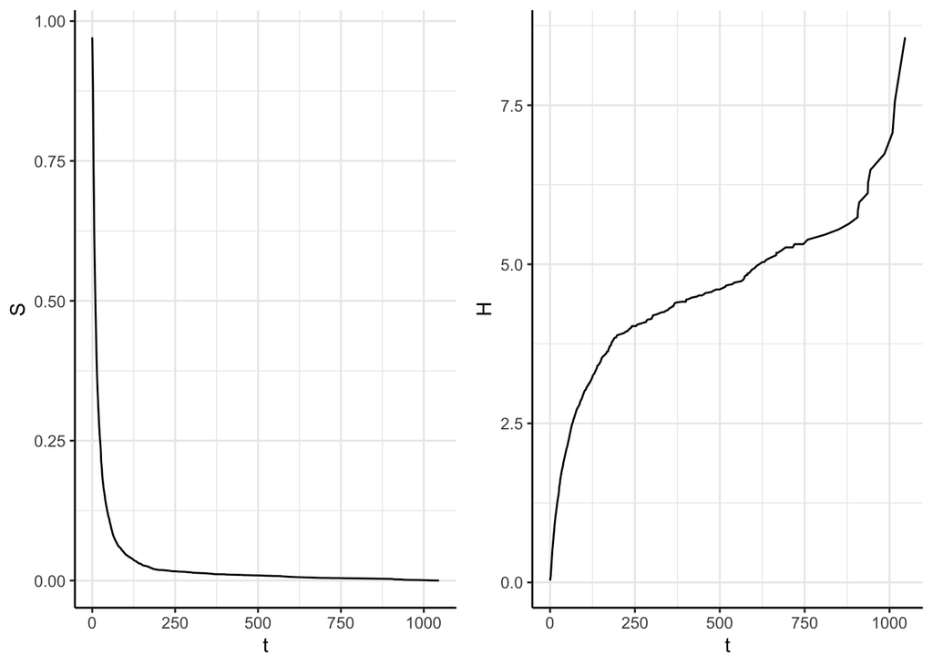

```r
dataINC <- read_csv("~/Dropbox/Enseignements/UNISTRA/MDD/data/data_INC_sample_agecl.csv")
# dataINC <- read_csv("~/Dropbox/Enseignements/UNISTRA/MDD/data/data_INC_tot.csv")

Xs <- as.numeric(dataINC$DateSortie - dataINC$DateEntree)
del <- dataINC$MotifReprise != "1 - En cours"
result.km <- survfit(Surv(Xs, del) ~ 1)
df_km <- data.frame(ts = result.km$time,
                    S = result.km$surv,
                    H = result.km$cumhaz
                    )



S_plot <- ggplot() + geom_line(data = df_km, mapping = aes(x = ts, y = S)) +   labs(x ="t", y = "S" ) + theme_bw() +
  theme(panel.border = element_blank(),
    panel.background = element_blank(), axis.line = element_line(colour = "black"))

H_plot <- ggplot() + geom_line(data = df_km, mapping = aes(x = ts, y = H)) +   labs(x ="t", y = "H" ) + theme_bw() +
  theme(panel.border = element_blank(),
    panel.background = element_blank(), axis.line = element_line(colour = "black"))
grid.arrange(S_plot, H_plot, ncol=2)
```

On peut estimer à partir de la fonction de survie empirique les taux de sortie et les comparer au taux de sortie estimé via l’estimateur empirique.

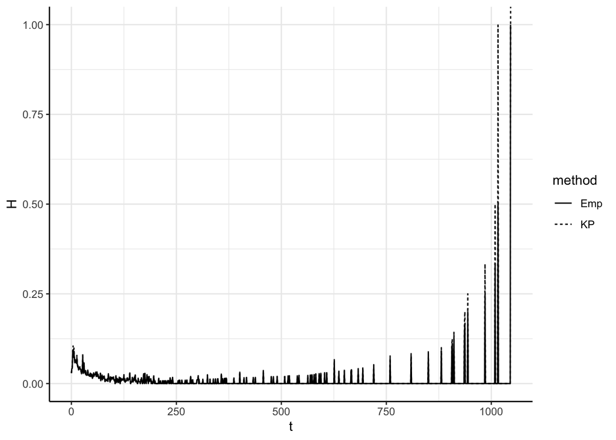

```r
# Estimation de Kaplan Meier des taux brut
# Fonction en escalier pour compenser l'absence d'observation pour certaine valeur de T
S <- stepfun(result.km$time, c(1,result.km$surv))
gridx <- seq(0, max(result.km$time), 1)

h_KP <- c(-diff(c(1,S(gridx))) / c(1,S(gridx)[-1]))

h_emp <- function(Xs, del){
  function(t) sum(Xs==t & del) / sum(Xs>=t)
}
h_hat <- h_emp(Xs,del)

df_h <- rbind(
  data.frame(ts = gridx, h = h_KP, method = "KP"),
  data.frame(ts = gridx, h = sapply(gridx, function(t) h_hat(t)), method = "Emp")
  )


h_plot <- ggplot() + geom_line(data = df_h, mapping = aes(x = ts, y = h, linetype = method)) +   labs(x ="t", y = "H" ) + theme_bw() +
  theme(panel.border = element_blank(),
    panel.background = element_blank(), axis.line = element_line(colour = "black"))
h_plot
```

Les estimations obtenues via ces deux méthodes sont très proches.

On réalise une courbe pour chaque classe d’âge.

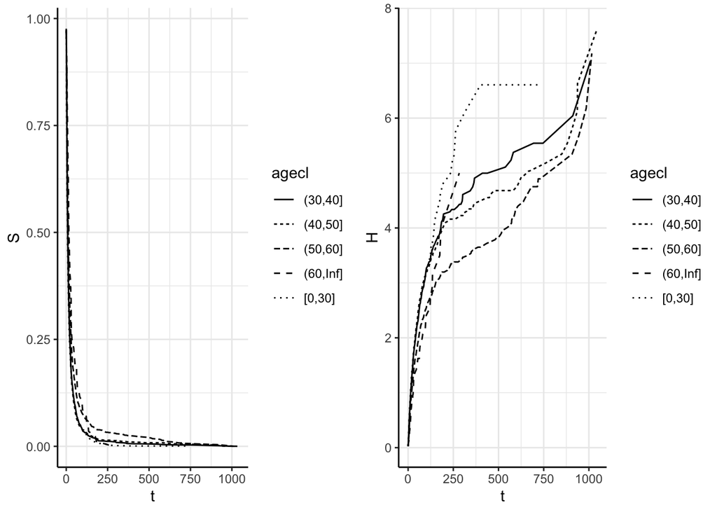

```r
agecls = levels(as.factor(dataINC$agecl))
df_km <- data.frame()

for(agecl in agecls){
  s <- dataINC$agecl == agecl
  result.km <- survfit(Surv(Xs[s], del[s]) ~ 1)
  res <- data.frame(ts = result.km$time,
                    S = result.km$surv,
                    H = result.km$cumhaz,
                    agecl = agecl
                    )
  df_km <- rbind(df_km,res)
}


S_plot <- ggplot() + geom_line(data = df_km, mapping = aes(x = ts, y = S, linetype = agecl)) +   labs(x ="t", y = "S" ) + theme_bw() +
  theme(panel.border = element_blank(),
    panel.background = element_blank(), axis.line = element_line(colour = "black"))


H_plot <- ggplot() + geom_line(data = df_km, mapping = aes(x = ts, y = H, linetype = agecl)) +   labs(x ="t", y = "H" ) + theme_bw() +
  theme(panel.border = element_blank(),
    panel.background = element_blank(), axis.line = element_line(colour = "black"))

grid.arrange(S_plot, H_plot, ncol=2)
```

On estime les taux brut pour chaque classe d’âge via l’estimateur de KP

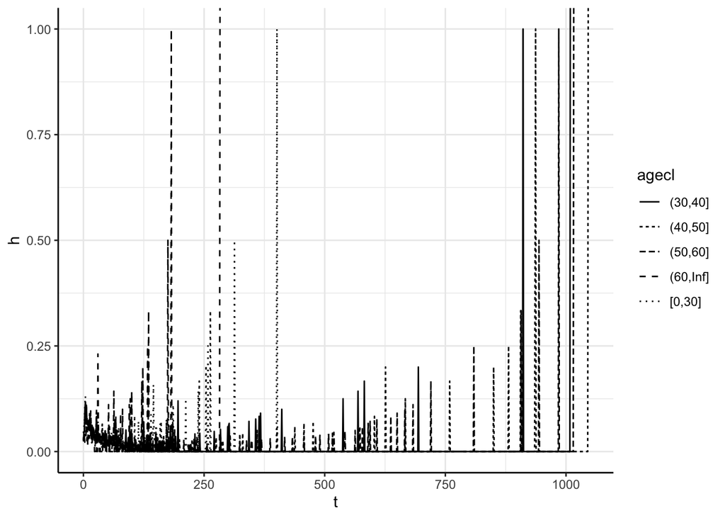

```r
df_km_h <- data.frame()
for(agecl in agecls){
  s <- dataINC$agecl == agecl
  result.km <- survfit(Surv(Xs[s], del[s]) ~ 1)
  S <- stepfun(result.km$time, c(1,result.km$surv))
  gridx <- seq(0, max(result.km$time), 1)
  res <- data.frame(ts = gridx,
                    h = c(-diff(c(1,S(gridx))) / c(1,S(gridx)[-1])),
                    agecl = agecl
                    )
  df_km_h <- rbind(df_km_h, res)
}

h_plot <- ggplot() + geom_line(data = df_km_h, mapping = aes(x = ts, y = h, linetype = agecl)) +   labs(x ="t", y = "h" ) + theme_bw() +
  theme(panel.border = element_blank(),
    panel.background = element_blank(), axis.line = element_line(colour = "black"))

h_plot
```

Nous avons estimé ici des “taux brut”, un post traitement doit être effectué pour les rendre exploitable. Il s’agit du lissage des taux bruts qui sera aborder dans un chapitre ultérieur.